# R Notebook - Meta-analysis by Louise M. Alissa (Opportunity for Sexual Selection)

**ALISSA, L.M. Effect of reproductive site limitation on the intensity of sexual selection and the quality of paternal care: a meta-analysis. 2018. Dissertação (Mestrado) - Instituto de Biociências, Universidade de São Paulo, SP.**

The availability of reproductive sites is a major factor shaping the behavior of males and females in species with resource-based mating systems. Using a meta-analytic approach, we tested five predictions directly or indirectly derived from the mating system theory. We expected that reproductive site limitation would lead to: (1) intense male-male competition for resource possession; (2) high variance in male reproductive success, generating high values of opportunity for sexual selection; (3) high intensity of selection on male traits related to resource possession; (4) high sperm competition risk; and (5) low quality of paternal care. We compiled information from observational and experimental studies that compared the reproductive behavior of individuals of the same species under low and high reproductive site limitation. We found that, when reproductive sites are limited, there is a slight increase in male-male competition, with higher rates of nest takeover and agonistic interactions, and a slight increase in the selection gradient on male traits, with successful males tending to be larger than unsuccessful males. Reproductive site limitation has no consistent effect on the opportunity for sexual selection and on the sperm competition risk. However, territorial males invest more in gonads and lose less paternity when reproductive sites are limited. There is also no clear effect of reproductive site limitation on the quality of paternal care, but few studies have addressed this subject. Taken together, our findings indicate that predictions on how reproductive site limitation affects several aspects of resource-based mating systems have weak empirical support. These predictions do not consider the plasticity in the mating tactics of males and females, which make them too simplistic. Moreover, since the original proposition of the mating system theory, our understanding of sperm competition increased a lot. We now know that accurate predictions on the intensity and direction of sexual selection should take into account both pre- and post-copulatory processes. Finally, the interplay between sexual selection and parental care is complex, and the original framework of mating system theory does not provide sufficient elements to derive clear and taxonomically broad predictions.

Louise Alissa de Morais

e-mail: louisem.alissa@gmail.com

# Organizing

## Loading libraries, setting working directory and loading data set

### Setting the work directory

```r
setwd("C:/Users/louis/Dropbox/Masters_analyses-LMAlissa")
```

### Opening packages

```r
library(metafor)
library(ggplot2)
library(phytools)
library(geiger)
library(picante)
library(MuMIn)
library(car)
library(ape)
library(Hmisc)
library(miscTools)
library(bbmle)
```

### Cleanning possible masking objects

```r
rm(list=ls())
```

### Opening the .csv file

```r
dataset2 <- read.csv(file="basic_dataset2.csv", header=T, dec=".", sep=";")
```

### Looking to data structure

```r
head(dataset2)
```

|  | ES | nID | study | publication_year | species | phylo | class | order | taxon | mating_system | care | male_engagement | exploited_resource | study_type | nest_availability_difference | resource_facet_manipulated | PRED | pred | response_variable | I_type | lnCRV | N |
| --- | --- | --- | --- | --- | --- | --- | --- | --- | --- | --- | --- | --- | --- | --- | --- | --- | --- | --- | --- | --- | --- | --- |
| 1 | E.S. 01 | 22 | Kelly 2008 | 2008 | Hemideina crassidens | Hemideina_crassidens | Insecta | Orthoptera | 1_artro | polygamy | maternal | no | tree hollows or artificial galleries | exp_field | NA | qualit | P2 - I calculation | mating success | mean haren size | SP | 0.7909686 | 37 |
| 2 | E.S. 02 | 22 | Kelly 2008 | 2008 | Hemideina crassidens | Hemideina_crassidens | Insecta | Orthoptera | 1_artro | polygamy | maternal | no | tree hollows or artificial galleries | exp_field | NA | qualit | P2 - I calculation | mating success | mean haren size | SP | 1.4442184 | 43 |
| 3 | E.S. 03 | 22 | Kelly 2008 | 2008 | Hemideina crassidens | Hemideina_crassidens | Insecta | Orthoptera | 1_artro | polygamy | maternal | no | tree hollows or artificial galleries | exp_field | NA | qualit | P2 - I calculation | mating success | mean haren size | SP | 0.8727989 | 27 |
| 4 | E.S. 04 | 22 | Kelly 2008 | 2008 | Hemideina crassidens | Hemideina_crassidens | Insecta | Orthoptera | 1_artro | polygamy | maternal | no | tree hollows or artificial galleries | exp_field | NA | qualit | P2 | sexual selection index | I mates | SP | -1.5707283 | 99 |
| 5 | E.S. 05 | 22 | Kelly 2008 | 2008 | Hemideina crassidens | Hemideina_crassidens | Insecta | Orthoptera | 1_artro | polygamy | maternal | no | tree hollows or artificial galleries | exp_field | NA | qualit | P2 | sexual selection index | I mates | SP | -0.5927875 | 85 |
| 6 | E.S. 06 | 22 | Kelly 2008 | 2008 | Hemideina crassidens | Hemideina_crassidens | Insecta | Orthoptera | 1_artro | polygamy | maternal | no | tree hollows or artificial galleries | exp_field | NA | qualit | P2 | sexual selection index | I mates | SP | -0.2981778 | 70 |

```r
tail(dataset2)
```

|  | ES | nID | study | publication_year | species | phylo | class | order | taxon | mating_system | care | male_engagement | exploited_resource | study_type | nest_availability_difference | resource_facet_manipulated | PRED | pred | response_variable | I_type | lnCRV | N |
| --- | --- | --- | --- | --- | --- | --- | --- | --- | --- | --- | --- | --- | --- | --- | --- | --- | --- | --- | --- | --- | --- | --- |
| 43 | E.S. 43 | 37 | Prohl 2002 | 2002 | Dendrobates pumilio | Dendrobates_pumilio | Amphibia | Anura | 3_anfi | polygamy | maternal | no | puddles | obs | yes | quant | P2 - I calculation | mating success | male mating success (n matings per male) | SP | 0.7597607 | 20 |
| 44 | E.S. 44 | 37 | Prohl 2002 | 2002 | Dendrobates pumilio | Dendrobates_pumilio | Amphibia | Anura | 3_anfi | polygamy | maternal | no | puddles | obs | yes | quant | P2 - I calculation | mating success | degree of polygyny (n of female mated per male) | SP | 0.4149259 | 28 |
| 45 | E.S. 45 | 37 | Prohl 2002 | 2002 | Dendrobates pumilio | Dendrobates_pumilio | Amphibia | Anura | 3_anfi | polygamy | maternal | no | puddles | obs | yes | quant | P2 - I calculation | mating success | degree of polygyny (n of female mated per male) | SP | 0.5003098 | 20 |
| 46 | E.S. 46 | 37 | Prohl 2002 | 2002 | Dendrobates pumilio | Dendrobates_pumilio | Amphibia | Anura | 3_anfi | polygamy | maternal | no | puddles | obs | yes | quant | P2 | sexual selection index | opportunity for sexual selection and coeficient of variance | SP | 0.8863384 | 28 |
| 47 | E.S. 47 | 37 | Prohl 2002 | 2002 | Dendrobates pumilio | Dendrobates_pumilio | Amphibia | Anura | 3_anfi | polygamy | maternal | no | puddles | obs | yes | quant | P2 | sexual selection index | opportunity for sexual selection and coeficient of variance | SP | 1.1856237 | 20 |
| 48 | E.S. 48 | 20 | Jacot et al 2009 | 2009 | Cyanistes caeruleus | Cyanistes_caeruleus | Aves | Passeriformes | 4_ave | polygamy | biparental | yes | tree hollows and nest box | exp_field | yes | quant | P2 - I calculation | reproductive success | mean clutch size | SP | 0.3950324 | 55 |

```r
str(dataset2)
```

```
'data.frame':   48 obs. of  22 variables:
 $ ES                          : Factor w/ 48 levels "E.S. 01","E.S. 02",..: 1 2 3 4 5 6 7 8 9 10 ...
 $ nID                         : int  22 22 22 22 22 22 22 46 29 29 ...
 $ study                       : Factor w/ 22 levels "Cogliati et al 2014",..: 5 5 5 5 5 5 5 22 10 10 ...
 $ publication_year            : Factor w/ 17 levels "1986","1987",..: 11 11 11 11 11 11 11 17 1 1 ...
 $ species                     : Factor w/ 17 levels "Archocentrus nigrofasciatus",..: 7 7 7 7 7 7 7 8 9 9 ...
 $ phylo                       : Factor w/ 17 levels "Archocentrus_nigrofasciatus",..: 7 7 7 7 7 7 7 8 9 9 ...
 $ class                       : Factor w/ 5 levels "Actinopterygii",..: 5 5 5 5 5 5 5 3 5 5 ...
 $ order                       : Factor w/ 9 levels " Scorpaeniformes",..: 7 7 7 7 7 7 7 6 5 5 ...
 $ taxon                       : Factor w/ 4 levels "1_artro","2_pisc",..: 1 1 1 1 1 1 1 1 1 1 ...
 $ mating_system               : Factor w/ 2 levels "monogamy","polygamy": 2 2 2 2 2 2 2 2 2 2 ...
 $ care                        : Factor w/ 4 levels "biparental","maternal",..: 2 2 2 2 2 2 2 4 3 3 ...
 $ male_engagement             : Factor w/ 2 levels "no","yes": 1 1 1 1 1 1 1 2 1 1 ...
 $ exploited_resource          : Factor w/ 15 levels "bivalve shells",..: 14 14 14 14 14 14 14 6 7 7 ...
 $ study_type                  : Factor w/ 3 levels "exp_field","exp_lab",..: 1 1 1 1 1 1 1 2 3 3 ...
 $ nest_availability_difference: Factor w/ 3 levels "no","yes","yes ": NA NA NA NA NA NA NA 2 2 2 ...
 $ resource_facet_manipulated  : Factor w/ 3 levels "dispo","qualit",..: 2 2 2 2 2 2 2 3 2 2 ...
 $ PRED                        : Factor w/ 2 levels "P2","P2 - I calculation": 2 2 2 1 1 1 1 2 2 1 ...
 $ pred                        : Factor w/ 3 levels "mating success",..: 1 1 1 3 3 3 3 3 1 3 ...
 $ response_variable           : Factor w/ 34 levels "degree of polygyny (n of female mated per male)",..: 13 13 13 3 3 3 3 28 14 7 ...
 $ I_type                      : Factor w/ 2 levels "CP","SP": 2 2 2 2 2 2 2 2 2 2 ...
 $ lnCRV                       : num  0.791 1.444 0.873 -1.571 -0.593 ...
 $ N                           : int  37 43 27 99 85 70 72 168 100 100 ...
```

### Setting the rigth classes for variables

```r
dataset2$nID <- as.factor(dataset2$nID)
dataset2$publication_year <- as.factor(dataset2$publication_year)
str(dataset2)
```

```
'data.frame':   48 obs. of  22 variables:
 $ ES                          : Factor w/ 48 levels "E.S. 01","E.S. 02",..: 1 2 3 4 5 6 7 8 9 10 ...
 $ nID                         : Factor w/ 22 levels "10","12","14",..: 5 5 5 5 5 5 5 18 9 9 ...
 $ study                       : Factor w/ 22 levels "Cogliati et al 2014",..: 5 5 5 5 5 5 5 22 10 10 ...
 $ publication_year            : Factor w/ 17 levels "1986","1987",..: 11 11 11 11 11 11 11 17 1 1 ...
 $ species                     : Factor w/ 17 levels "Archocentrus nigrofasciatus",..: 7 7 7 7 7 7 7 8 9 9 ...
 $ phylo                       : Factor w/ 17 levels "Archocentrus_nigrofasciatus",..: 7 7 7 7 7 7 7 8 9 9 ...
 $ class                       : Factor w/ 5 levels "Actinopterygii",..: 5 5 5 5 5 5 5 3 5 5 ...
 $ order                       : Factor w/ 9 levels " Scorpaeniformes",..: 7 7 7 7 7 7 7 6 5 5 ...
 $ taxon                       : Factor w/ 4 levels "1_artro","2_pisc",..: 1 1 1 1 1 1 1 1 1 1 ...
 $ mating_system               : Factor w/ 2 levels "monogamy","polygamy": 2 2 2 2 2 2 2 2 2 2 ...
 $ care                        : Factor w/ 4 levels "biparental","maternal",..: 2 2 2 2 2 2 2 4 3 3 ...
 $ male_engagement             : Factor w/ 2 levels "no","yes": 1 1 1 1 1 1 1 2 1 1 ...
 $ exploited_resource          : Factor w/ 15 levels "bivalve shells",..: 14 14 14 14 14 14 14 6 7 7 ...
 $ study_type                  : Factor w/ 3 levels "exp_field","exp_lab",..: 1 1 1 1 1 1 1 2 3 3 ...
 $ nest_availability_difference: Factor w/ 3 levels "no","yes","yes ": NA NA NA NA NA NA NA 2 2 2 ...
 $ resource_facet_manipulated  : Factor w/ 3 levels "dispo","qualit",..: 2 2 2 2 2 2 2 3 2 2 ...
 $ PRED                        : Factor w/ 2 levels "P2","P2 - I calculation": 2 2 2 1 1 1 1 2 2 1 ...
 $ pred                        : Factor w/ 3 levels "mating success",..: 1 1 1 3 3 3 3 3 1 3 ...
 $ response_variable           : Factor w/ 34 levels "degree of polygyny (n of female mated per male)",..: 13 13 13 3 3 3 3 28 14 7 ...
 $ I_type                      : Factor w/ 2 levels "CP","SP": 2 2 2 2 2 2 2 2 2 2 ...
 $ lnCRV                       : num  0.791 1.444 0.873 -1.571 -0.593 ...
 $ N                           : int  37 43 27 99 85 70 72 168 100 100 ...
```

## Loanding and dealing with the phylogeny

### First, opening the file .tree (newik). The tree was constructed on Mesquite.

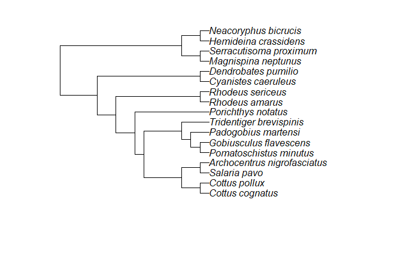

```r
tree2 <- read.tree('mytree2_mod.tre')
plot(tree2)
```

### Calculating the correlation matrix, with weighted values for relatedness

```r
tree2_mod <- compute.brlen(tree2, method="Grafen")
cor <- vcv(tree2_mod, corr =T)
```

### Cheking if every specie in the data is present in the tree

```r
spp <- data.frame(spp = unique(dataset2$phylo))
row.names(spp) <- spp$spp
```

```r
check.phylo <- name.check(tree2_mod, spp)
check.phylo
```

```
[1] "OK"
```

# Selecting the random-effects based on AICc

Randon variables: the effect size identity (id.mc), the article identity(nID), species (species) and the phylogenetic effect (phylo). Without moderators here.

### Creating an object for list each effect size

```r
id.op <- as.factor(1:(length(dataset2$lnCRV)))
```

### Creating an object for variance estimates values

```r
var.estimative <- 1/(dataset2$N-3)
dataset2 <- cbind(dataset2, var.estimative)
```

### Constructing models

```r
# id |--> AICc =  159.2597
m_randon1 <- rma.mv(yi=lnCRV, V=var.estimative, random = list(~ 1|id.op), data=dataset2, method="ML")
summary(m_randon1)
```

```
Multivariate Meta-Analysis Model (k = 48; method: ML)

  logLik  Deviance       AIC       BIC      AICc
-77.4965  263.5482  158.9930  162.7354  159.2597

Variance Components:

            estim    sqrt  nlvls  fixed  factor
sigma^2    1.4429  1.2012     48     no   id.op

Test for Heterogeneity:
Q(df = 47) = 4687.8271, p-val < .0001

Model Results:

estimate      se    zval    pval    ci.lb   ci.ub
  0.3068  0.1748  1.7552  0.0792  -0.0358  0.6494  .

---
Signif. codes:  0 *** 0.001 ** 0.01 * 0.05 . 0.1   1
```

```r
# id + phylo |--> AICc = 161.5355
m_randon2 <- rma.mv(yi=lnCRV, V=var.estimative, random = list(~ 1|id.op, ~1|phylo),R=list(phylo=cor), data=dataset2, method="ML")
summary(m_randon2)
```

```
Multivariate Meta-Analysis Model (k = 48; method: ML)

  logLik  Deviance       AIC       BIC      AICc
-77.4950  263.5453  160.9901  166.6037  161.5355

Variance Components:

            estim    sqrt  nlvls  fixed  factor    R
sigma^2.1  1.4378  1.1991     48     no   id.op   no
sigma^2.2  0.0051  0.0714     17     no   phylo  yes

Test for Heterogeneity:
Q(df = 47) = 4687.8271, p-val < .0001

Model Results:

estimate      se    zval    pval    ci.lb   ci.ub
  0.3092  0.1794  1.7238  0.0847  -0.0424  0.6608  .

---
Signif. codes:  0 *** 0.001 ** 0.01 * 0.05 . 0.1   1
```

```r
# id + species |--> AICc = 161.5385
m_randon3 <- rma.mv(yi=lnCRV, V=var.estimative, random = list(~ 1|id.op, ~1|species), data=dataset2, method="ML")
summary(m_randon3)
```

```
Multivariate Meta-Analysis Model (k = 48; method: ML)

  logLik  Deviance       AIC       BIC      AICc
-77.4965  263.5482  160.9930  166.6066  161.5385

Variance Components:

            estim    sqrt  nlvls  fixed   factor
sigma^2.1  1.4429  1.2012     48     no    id.op
sigma^2.2  0.0000  0.0001     17     no  species

Test for Heterogeneity:
Q(df = 47) = 4687.8271, p-val < .0001

Model Results:

estimate      se    zval    pval    ci.lb   ci.ub
  0.3068  0.1748  1.7552  0.0792  -0.0358  0.6494  .

---
Signif. codes:  0 *** 0.001 ** 0.01 * 0.05 . 0.1   1
```

```r
# id + nID |--> AICc = 161.5132
m_randon4 <- rma.mv(yi=lnCRV, V=var.estimative, random = list(~ 1|id.op, ~1|nID), data=dataset2, method="ML")
summary(m_randon4)
```

```
Multivariate Meta-Analysis Model (k = 48; method: ML)

  logLik  Deviance       AIC       BIC      AICc
-77.4839  263.5230  160.9678  166.5814  161.5132

Variance Components:

            estim    sqrt  nlvls  fixed  factor
sigma^2.1  1.4173  1.1905     48     no   id.op
sigma^2.2  0.0256  0.1599     22     no     nID

Test for Heterogeneity:
Q(df = 47) = 4687.8271, p-val < .0001

Model Results:

estimate      se    zval    pval    ci.lb   ci.ub
  0.2971  0.1784  1.6648  0.0960  -0.0527  0.6468  .

---
Signif. codes:  0 *** 0.001 ** 0.01 * 0.05 . 0.1   1
```

```r
# id + specie + phylo |--> AICc = 163.9232
m_randon5 <- rma.mv(yi=lnCRV, V=var.estimative, random = list(~ 1|id.op, ~1|species, ~1|phylo), R=list(phylo=cor), data=dataset2, method="ML")
summary(m_randon5)
```

```
Multivariate Meta-Analysis Model (k = 48; method: ML)

  logLik  Deviance       AIC       BIC      AICc
-77.4965  263.5482  162.9930  170.4778  163.9232

Variance Components:

            estim    sqrt  nlvls  fixed   factor    R
sigma^2.1  1.4429  1.2012     48     no    id.op   no
sigma^2.2  0.0000  0.0008     17     no  species   no
sigma^2.3  0.0000  0.0014     17     no    phylo  yes

Test for Heterogeneity:
Q(df = 47) = 4687.8271, p-val < .0001

Model Results:

estimate      se    zval    pval    ci.lb   ci.ub
  0.3068  0.1748  1.7552  0.0792  -0.0358  0.6494  .

---
Signif. codes:  0 *** 0.001 ** 0.01 * 0.05 . 0.1   1
```

```r
# id + nID + specie |--> AICc = 163.8980
m_randon6 <- rma.mv(yi=lnCRV, V=var.estimative, random = list(~ 1|id.op, ~1|nID, ~1|species), data=dataset2, method="ML")
summary(m_randon6)
```

```
Multivariate Meta-Analysis Model (k = 48; method: ML)

  logLik  Deviance       AIC       BIC      AICc
-77.4839  263.5230  162.9678  170.4526  163.8980

Variance Components:

            estim    sqrt  nlvls  fixed   factor
sigma^2.1  1.4173  1.1905     48     no    id.op
sigma^2.2  0.0256  0.1599     22     no      nID
sigma^2.3  0.0000  0.0001     17     no  species

Test for Heterogeneity:
Q(df = 47) = 4687.8271, p-val < .0001

Model Results:

estimate      se    zval    pval    ci.lb   ci.ub
  0.2971  0.1784  1.6648  0.0960  -0.0527  0.6468  .

---
Signif. codes:  0 *** 0.001 ** 0.01 * 0.05 . 0.1   1
```

```r
# id + nID + phylo |--> AICc = 163.8980
m_randon7 <- rma.mv(yi=lnCRV, V=var.estimative, random = list(~ 1|id.op, ~1|nID, ~1|phylo),R=list(phylo=cor), data=dataset2, method="ML")
summary(m_randon7)
```

```
Multivariate Meta-Analysis Model (k = 48; method: ML)

  logLik  Deviance       AIC       BIC      AICc
-77.4839  263.5230  162.9678  170.4526  163.8980

Variance Components:

            estim    sqrt  nlvls  fixed  factor    R
sigma^2.1  1.4173  1.1905     48     no   id.op   no
sigma^2.2  0.0256  0.1599     22     no     nID   no
sigma^2.3  0.0000  0.0001     17     no   phylo  yes

Test for Heterogeneity:
Q(df = 47) = 4687.8271, p-val < .0001

Model Results:

estimate      se    zval    pval    ci.lb   ci.ub
  0.2971  0.1784  1.6648  0.0960  -0.0527  0.6468  .

---
Signif. codes:  0 *** 0.001 ** 0.01 * 0.05 . 0.1   1
```

```r
# id + nID + specie + phylo |--> AICc = 166.3963
m_randon8 <- rma.mv(yi=lnCRV, V=var.estimative, random = list(~ 1|id.op, ~1|nID, ~1|species, ~1|phylo), R=list(phylo=cor), data=dataset2, method="ML")
summary(m_randon8)
```

```
Multivariate Meta-Analysis Model (k = 48; method: ML)

  logLik  Deviance       AIC       BIC      AICc
-77.4839  263.5230  164.9678  174.3238  166.3963

Variance Components:

            estim    sqrt  nlvls  fixed   factor    R
sigma^2.1  1.4173  1.1905     48     no    id.op   no
sigma^2.2  0.0256  0.1599     22     no      nID   no
sigma^2.3  0.0000  0.0000     17     no  species   no
sigma^2.4  0.0000  0.0001     17     no    phylo  yes

Test for Heterogeneity:
Q(df = 47) = 4687.8271, p-val < .0001

Model Results:

estimate      se    zval    pval    ci.lb   ci.ub
  0.2971  0.1784  1.6648  0.0960  -0.0527  0.6468  .

---
Signif. codes:  0 *** 0.001 ** 0.01 * 0.05 . 0.1   1
```

### Creating a table to compare models, looking for AICc

```r
ICtab(m_randon1, m_randon2, m_randon3, m_randon4, m_randon5, m_randon7, m_randon8, type= "AICc")
```

```
          dAICc df
m_randon1 0.0   2
m_randon4 2.3   3
m_randon2 2.3   3
m_randon3 2.3   3
m_randon7 4.6   4
m_randon5 4.7   4
m_randon8 7.1   5
```

# Performing - data set 2 - Opportunity for sexual selection

## The meta-analytic model

Randon variables: the effect size identity, the article identity, species and the phylogenetic effect. Without moderators here.

```r
meta.op.phylo <- rma.mv(yi=lnCRV, V=var.estimative, random = list(~ 1|id.op, ~1|nID, ~1|species, ~1|phylo), R=list(phylo=cor) , data=dataset2, method="REML")
```

### Looking the results

```r
summary(meta.op.phylo)
```

```
Multivariate Meta-Analysis Model (k = 48; method: REML)

  logLik  Deviance       AIC       BIC      AICc
-76.2397  152.4794  162.4794  171.7301  163.9428

Variance Components:

            estim    sqrt  nlvls  fixed   factor    R
sigma^2.1  1.4280  1.1950     48     no    id.op   no
sigma^2.2  0.0000  0.0001     22     no      nID   no
sigma^2.3  0.0000  0.0000     17     no  species   no
sigma^2.4  0.0652  0.2554     17     no    phylo  yes

Test for Heterogeneity:
Q(df = 47) = 4687.8271, p-val < .0001

Model Results:

estimate      se    zval    pval    ci.lb   ci.ub
  0.3249  0.2278  1.4263  0.1538  -0.1216  0.7714

---
Signif. codes:  0 *** 0.001 ** 0.01 * 0.05 . 0.1   1
```

### Basic forest plot (made with metafor package)

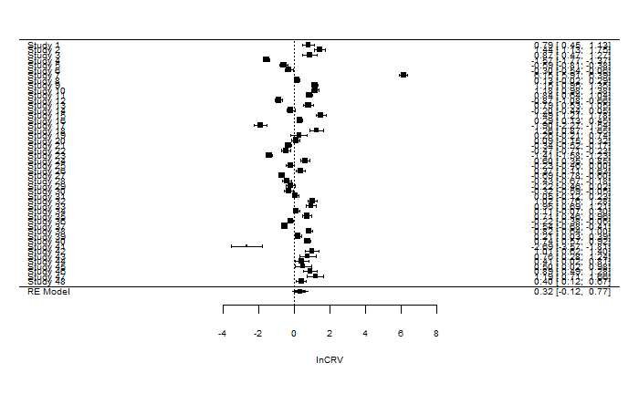

```r
forest(meta.op.phylo, cex=.6, xlab="lnCRV")
```

## Heterogeinity

*Based in Nakagawa & Santos (2012)*

```r
dataset2$wi <- 1/dataset2$var.estimative # precision = 1 / standard error of effect size (Equation 20; Nakagawa & Santos 2012)
```

```r
s2m.op <- sum(dataset2$wi*(length(dataset2$wi)-1))/(sum(dataset2$wi)^2-sum(dataset2$wi^2)) #(Equation 22; Nakagawa & Santos 2012)
s2m.op #s^2_m variation within study
```

```
[1] 0.01260994
```

```r
s2t.op <- sum(meta.op.phylo$sigma2) + s2m.op
s2t.op #s^2_t variation total
```

```
[1] 1.505823
```

### The total amount of variance

```r
total_I2.op <- sum(meta.op.phylo$sigma2)/s2t.op
total_I2.op*100 # the "total" variation
```

```
[1] 99.16259
```

### Proportion of variance from effect size id

```r
id.op_I2 <- meta.op.phylo$sigma2[1]/s2t.op
id.op_I2*100
```

```
[1] 94.83133
```

### Proportion of variance from study id

```r
nID_I2 <- meta.op.phylo$sigma2[2]/s2t.op
nID_I2*100
```

```
[1] 8.808637e-07
```

### Proportion of variance from species id

```r
especies_I2 <- meta.op.phylo$sigma2[3]/s2t.op
especies_I2*100
```

```
[1] 1.364828e-12
```

### Proportion of variance from phylo

```r
phylo_I2 <- meta.op.phylo$sigma2[4]/s2t.op
phylo_I2*100
```

```
[1] 4.331259
```

## The phylogenetic effect

Low, in this case.

```r
H2.op<-meta.op.phylo$sigma2[4] / sum(meta.op.phylo$sigma2)
H2.op*100
```

```
[1] 4.367836
```

## Qb

Testing if the mean effect is different in different taxa.

```r
mean_taxon <- rma.mv(yi=lnCRV, V=var.estimative, random = list(~ 1|id.op, ~1|nID, ~1|species, ~1|phylo), R=list(phylo=cor) , data=dataset2, method="REML", mod= ~ taxon-1)
summary(mean_taxon)
```

```
Multivariate Meta-Analysis Model (k = 48; method: REML)

  logLik  Deviance       AIC       BIC      AICc
-70.9237  141.8474  157.8474  172.1209  161.9616

Variance Components:

            estim    sqrt  nlvls  fixed   factor    R
sigma^2.1  1.4382  1.1993     48     no    id.op   no
sigma^2.2  0.0000  0.0001     22     no      nID   no
sigma^2.3  0.0000  0.0000     17     no  species   no
sigma^2.4  0.0000  0.0000     17     no    phylo  yes

Test for Residual Heterogeneity:
QE(df = 44) = 4303.3271, p-val < .0001

Test of Moderators (coefficient(s) 1:4):
QM(df = 4) = 7.3584, p-val = 0.1181

Model Results:

              estimate      se     zval    pval    ci.lb   ci.ub
taxon1_artro    0.6999  0.3223   2.1715  0.0299   0.0682  1.3317  *
taxon2_pisc    -0.0071  0.2325  -0.0304  0.9758  -0.4628  0.4487
taxon3_anfi     0.7928  0.4979   1.5922  0.1113  -0.1831  1.7687
taxon4_ave      0.3950  1.2073   0.3272  0.7435  -1.9711  2.7612

---
Signif. codes:  0 *** 0.001 ** 0.01 * 0.05 . 0.1   1
```

# Testing publication bias

## Egger’s regression

### Radial figure

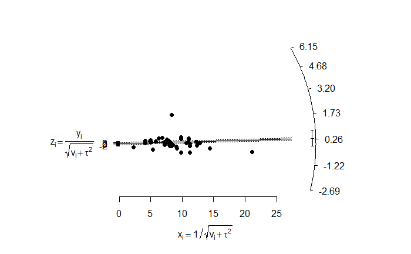

```r
# Egger's figure
radial.rma(meta.op.phylo)
```

### Egger’s regression test

Non significant

```r
s.e.op <- sqrt(var.estimative)
precision.op <- 1/s.e.op
Egger.op <- lm(dataset2$lnCRV*precision.op ~ precision.op)
summary(Egger.op)
```

```
Call:
lm(formula = dataset2$lnCRV * precision.op ~ precision.op)

Residuals:
    Min      1Q  Median      3Q     Max
-16.460  -4.141   0.062   3.291  49.035

Coefficients:
             Estimate Std. Error t value Pr(>|t|)
(Intercept)    7.5613     3.8840   1.947   0.0577 .
precision.op  -0.6625     0.4327  -1.531   0.1326
---
Signif. codes:  0 *** 0.001 ** 0.01 * 0.05 . 0.1   1

Residual standard error: 9.703 on 46 degrees of freedom
Multiple R-squared:  0.04849,   Adjusted R-squared:  0.0278
F-statistic: 2.344 on 1 and 46 DF,  p-value: 0.1326
```

## Funnel Plot

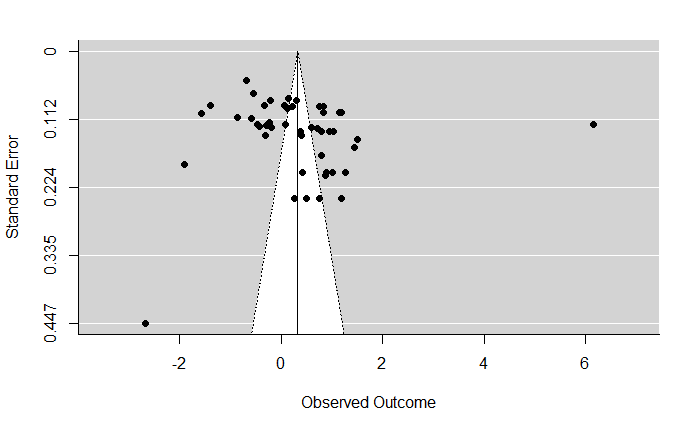

```r
# Basic funnel plot
funnel(meta.op.phylo)
```

```r
#plot 1 ("plot")
plot(dataset2$lnCRV,
     precision.op,
     xlab="lnCRV",
     ylab="precision (1/N-3)",
     cex=1.5,
     xlim=c(min(var.estimative, na.rm=T)-0.5,max(dataset2$lnCRV, na.rm=T)+0.5),
     ylim=c(0,max(precision.op, na.rm=T)*1.2))
abline(v=meta.op.phylo[1], lwd=3)
```

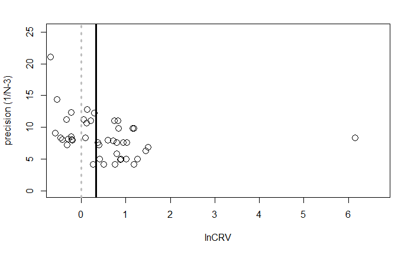

```r
abline(v=0, col=8, lwd=3, lty="dotted")
```

```r
#plot 2 ("ggplot")
dataset2$precision.op <-precision.op
funnel_2 <- ggplot(dataset2, aes(x=lnCRV, y=precision.op)) +
  geom_point(size=4, colour="gray30") +
  scale_shape(solid=FALSE) +
  xlab("lnCRV ") +
  ylab("Precision (1/N-3)") +
  theme_classic(base_size = 23)+
  geom_vline(xintercept=0, size=1.1, colour="gray", linetype = 1)+
  geom_vline(xintercept=0.1663, size=1.1, linetype = 1)+
  theme(axis.title.x=element_text(vjust=-0.1))+
  theme(axis.title.y=element_text(vjust=1.2))
```

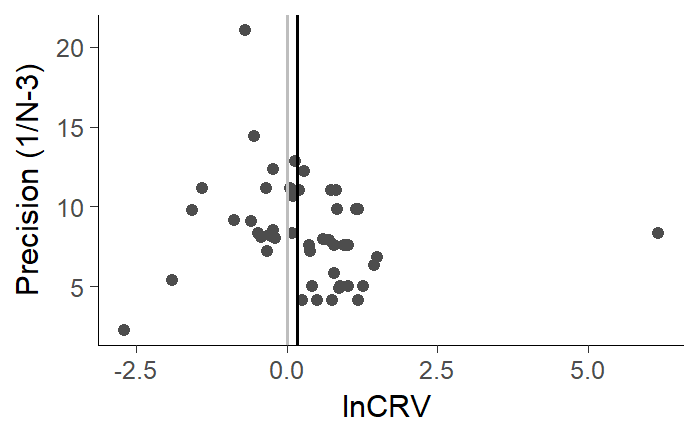

```r
funnel_2
```

# Moderators

## Type of methodological approach

Testing if differences between study methods (obs, exp_lab, exp_field) explain variance in data

```r
meta.op_mod1 <- rma.mv(yi=lnCRV, V=var.estimative, random = list(~ 1|id.op, ~1|nID, ~1|species, ~1|phylo), R=list(phylo=cor) , data=dataset2, method="REML", mod= ~ study_type-1)
summary(meta.op_mod1)
```

```
Multivariate Meta-Analysis Model (k = 48; method: REML)

  logLik  Deviance       AIC       BIC      AICc
-73.7650  147.5300  161.5300  174.1766  164.5570

Variance Components:

            estim    sqrt  nlvls  fixed   factor    R
sigma^2.1  1.4716  1.2131     48     no    id.op   no
sigma^2.2  0.0401  0.2002     22     no      nID   no
sigma^2.3  0.0000  0.0001     17     no  species   no
sigma^2.4  0.0224  0.1498     17     no    phylo  yes

Test for Residual Heterogeneity:
QE(df = 45) = 4549.8718, p-val < .0001

Test of Moderators (coefficient(s) 1:3):
QM(df = 3) = 2.5525, p-val = 0.4659

Model Results:

                     estimate      se    zval    pval    ci.lb   ci.ub
study_typeexp_field    0.4330  0.3173  1.3648  0.1723  -0.1888  1.0549
study_typeexp_lab      0.1454  0.3802  0.3825  0.7021  -0.5998  0.8907
study_typeobs          0.2744  0.3158  0.8690  0.3849  -0.3445  0.8934

---
Signif. codes:  0 *** 0.001 ** 0.01 * 0.05 . 0.1   1
```

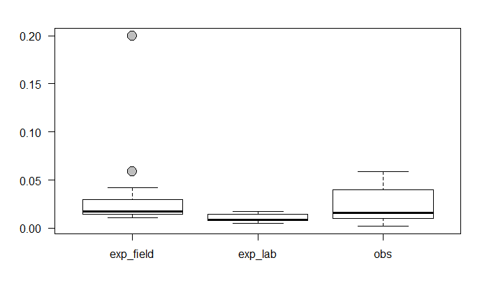

```r
plot(dataset2$study_type, var.estimative, las = 1, bty = "l", cex = 2, pch=21, bg=16)
```

```r
table(dataset2$study_type)
```

```
exp_field   exp_lab       obs
       18        12        18
```

## Type of mating system

Testing if differences between monogamy and polygamy mating systems explain variance in data

```r
# social_bond
meta.op_mod22 <- rma.mv(yi=lnCRV, V=var.estimative, random = list(~ 1|id.op, ~1|nID, ~1|species, ~1|phylo), R=list(phylo=cor) , data=dataset2, method="REML", mod= ~ mating_system -1)
summary(meta.op_mod22)
```

```
Multivariate Meta-Analysis Model (k = 48; method: REML)

  logLik  Deviance       AIC       BIC      AICc
-74.5309  149.0618  161.0618  172.0337  163.2157

Variance Components:

            estim    sqrt  nlvls  fixed   factor    R
sigma^2.1  1.4084  1.1868     48     no    id.op   no
sigma^2.2  0.0000  0.0001     22     no      nID   no
sigma^2.3  0.0000  0.0000     17     no  species   no
sigma^2.4  0.0941  0.3068     17     no    phylo  yes

Test for Residual Heterogeneity:
QE(df = 46) = 4598.5850, p-val < .0001

Test of Moderators (coefficient(s) 1:2):
QM(df = 2) = 2.9867, p-val = 0.2246

Model Results:

                       estimate      se    zval    pval    ci.lb   ci.ub
mating_systemmonogamy    1.6566  1.2296  1.3472  0.1779  -0.7534  4.0666
mating_systempolygamy    0.3002  0.2480  1.2105  0.2261  -0.1859  0.7864

---
Signif. codes:  0 *** 0.001 ** 0.01 * 0.05 . 0.1   1
```

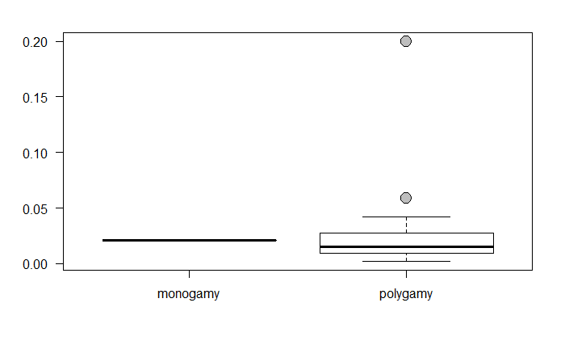

```r
plot(dataset2$mating_system, var.estimative, las = 1, bty = "l", cex = 2, pch=21, bg=16)
```

```r
table(dataset2$mating_system)
```

```
monogamy polygamy
       1       47
```

## Type of parental care

Testing if differences between parental care type (maternal, paternal, biparental, no_care) explain variance in data

```r
meta.op_mod3 <- rma.mv(yi=lnCRV, V=var.estimative, random = list(~ 1|id.op, ~1|nID, ~1|species, ~1|phylo), R=list(phylo=cor) , data=dataset2, method="REML", mod= ~ care-1)
summary(meta.op_mod3)
```

```
Multivariate Meta-Analysis Model (k = 48; method: REML)

  logLik  Deviance       AIC       BIC      AICc
-71.0540  142.1079  158.1079  172.3815  162.2222

Variance Components:

            estim    sqrt  nlvls  fixed   factor    R
sigma^2.1  1.4431  1.2013     48     no    id.op   no
sigma^2.2  0.0000  0.0000     22     no      nID   no
sigma^2.3  0.0000  0.0000     17     no  species   no
sigma^2.4  0.0000  0.0000     17     no    phylo  yes

Test for Residual Heterogeneity:
QE(df = 44) = 4308.4217, p-val < .0001

Test of Moderators (coefficient(s) 1:4):
QM(df = 4) = 7.0769, p-val = 0.1319

Model Results:

                estimate      se     zval    pval    ci.lb   ci.ub
carebiparental    0.9435  0.8554   1.1031  0.2700  -0.7330  2.6200
carematernal      0.7030  0.3035   2.3166  0.0205   0.1082  1.2978  *
careno_care       0.3197  0.4597   0.6954  0.4868  -0.5813  1.2206
carepaternal     -0.0251  0.2518  -0.0995  0.9207  -0.5186  0.4685

---
Signif. codes:  0 *** 0.001 ** 0.01 * 0.05 . 0.1   1
```

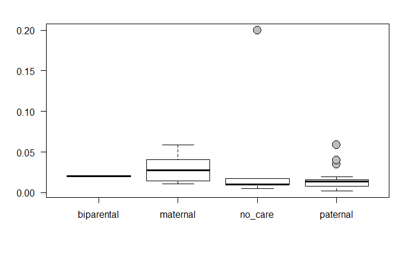

```r
plot(dataset2$care, var.estimative, las = 1, bty = "l", cex = 2, pch=21, bg=16)
```

```r
table(dataset2$care)
```

```
biparental   maternal    no_care   paternal
         2         16          7         23
```

## Type of I

Testing if the type I calculation explain the variance, CP (with paternity data) and SP (withou paternity data)

```r
meta.op_mod5 <- rma.mv(yi=lnCRV, V=var.estimative, random = list(~ 1|id.op, ~1|nID, ~1|species, ~1|phylo), R=list(phylo=cor) , data=dataset2, method="REML", mod= ~ I_type-1)
summary(meta.op_mod5)
```

```
Multivariate Meta-Analysis Model (k = 48; method: REML)

  logLik  Deviance       AIC       BIC      AICc
-74.8143  149.6287  161.6287  172.6005  163.7825

Variance Components:

            estim    sqrt  nlvls  fixed   factor    R
sigma^2.1  1.4587  1.2078     48     no    id.op   no
sigma^2.2  0.0000  0.0001     22     no      nID   no
sigma^2.3  0.0000  0.0000     17     no  species   no
sigma^2.4  0.0312  0.1767     17     no    phylo  yes

Test for Residual Heterogeneity:
QE(df = 46) = 4640.3301, p-val < .0001

Test of Moderators (coefficient(s) 1:2):
QM(df = 2) = 3.1099, p-val = 0.2112

Model Results:

          estimate      se     zval    pval    ci.lb   ci.ub
I_typeCP   -0.1627  0.6239  -0.2608  0.7942  -1.3855  1.0601
I_typeSP    0.3595  0.2096   1.7150  0.0863  -0.0514  0.7704  .

---
Signif. codes:  0 *** 0.001 ** 0.01 * 0.05 . 0.1   1
```

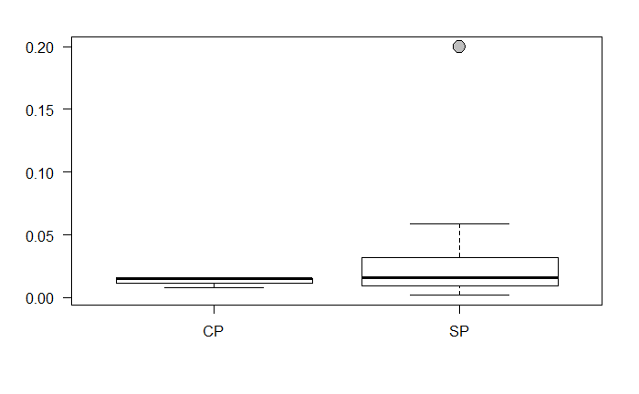

```r
plot(dataset2$I_type, var.estimative, las = 1, bty = "l", cex = 2, pch=21, bg=16)
```

```r
table(dataset2$I_type)
```

```
CP SP
 4 44
```

# Making a better forest plot

```r
mean.effect <- as.data.frame(matrix(t(mean.effect),nrow=1),stringsAsFactors=FALSE)
class(mean.effect)
```

```
[1] "data.frame"
```

```r
df2.2$lnCRV <- as.character(df2.2$lnCRV)
df2.2$CILB <- as.character(df2.2$CILB)
df2.2$CIUB <- as.character(df2.2$CIUB)
```

```r
df2.2$lnCRV <- as.numeric(df2.2$lnCRV)
df2.2$CILB <- as.numeric(df2.2$CILB)
df2.2$CIUB <- as.numeric(df2.2$CIUB)
```

```r
highlight <- subset(df2.2, ES=="Mean effect size")
```

Now, creating the plot

```r
myplot_2 <- ggplot(df2.2, aes(x=ES)) +
  geom_hline(aes(yintercept=0), linetype="dashed", color="gray", lwd=1) +
  geom_linerange(aes(x=ES, ymin=CILB, ymax=CIUB),col="gray50", lwd=1, alpha=0.7) +
   geom_linerange(aes(x=ES, ymin=CILB, ymax=CIUB), data=highlight, colour="black") +
  geom_point(aes(y=lnCRV, size=lnCRV), shape = 21, fill="gray50", col="gray50") +
   geom_point(aes(y=lnCRV, size=lnCRV), data=highlight, colour="black") +
  scale_size_continuous(range = c(1,5), name="Effect size lnCRV") +
  scale_x_discrete(limits = rev(levels(df2.2$ES)))+
  ylab(expression(Effect~Size~lnCRV))+
  xlab("")+
  theme_bw()+
  coord_flip()+
  guides(fill= guide_legend(override.aes = list(size=5)),
         size = guide_legend(override.aes = list(fill = "gray40")))+
  theme(panel.border = element_blank(),
        panel.grid.major = element_blank(),
        panel.grid.minor = element_blank(),
        axis.text.x = element_text(size=12),
        axis.text.y = element_text(size=10),
        axis.line = element_line(colour = "black"),
        legend.position = "none")
```

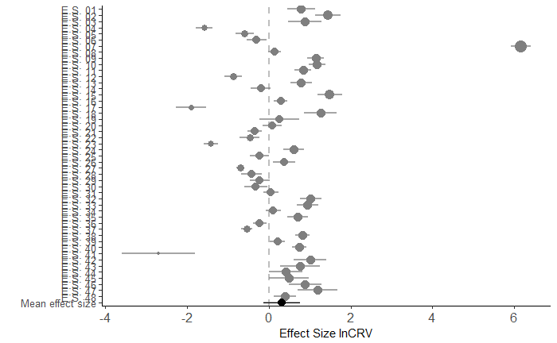

```r
myplot_2
```